# Ridge Regression

## Ridge Regression

### What is Ridge Regression?

Ridge regression, also known as Tikhonov regularization, is a type of linear regression that incorporates a regularization term to address specific challenges that arise in ordinary least squares (OLS) regression. Unlike standard regression, which minimizes only the residual sum of squares, ridge regression adds a penalty proportional to the square of the magnitude of coefficients, thus shrinking their values.

### Mathematical Formulation

Ridge regression minimizes the following objective function:

$$\min_{\beta} \|y - X\beta\|^2 +
\lambda\|\beta\|^2$$

where:

- $X$: The design matrix of predictors (independent variables).
- $y$: The response vector (dependent variable).
- $\beta$: The vector of regression coefficients.
- $\lambda$: A non-negative regularization parameter that controls the strength of the penalty term.

By tuning the regularization parameter $\lambda$, ridge regression balances model complexity and performance, leading to more stable predictions.

### A Type of Linear Regression with Regularization

Ridge regression extends OLS by adding the penalty term $\lambda\|\beta\|^2$. This modification helps control the model complexity, reducing the risk of overfitting when the model is too flexible or when multicollinearity (high correlation among predictors) is present.

### The Problem of Overfitting and Multicollinearity

1. **Overfitting:** Overfitting occurs when a model captures noise in the training data rather than the underlying data distribution. This results in poor performance on unseen data. Overfitting is common when the number of predictors is large or when the model is too complex relative to the data size.
2. **Multicollinearity:** In multicollinearity, predictors are highly correlated, causing instability in OLS coefficient estimates. This instability arises because the matrix $X^TX$ becomes nearly singular, leading to large variances in estimated coefficients. Small changes in data can result in disproportionately large changes in the coefficients.

For example, if the condition number of $X^TX$ is very large, the system of normal equations:

$$X^TX\beta = X^Ty$$

becomes numerically unstable.

### In simple terms Ridge regression…

- It modifies the standard linear regression equation by adding a penalty term to the loss function.
- The standard OLS loss function:

$$\min_{\beta} \sum(y_i -
X_i\beta)^2$$

- Ridge Regression adds a penalty:

$$\min_{\beta} \sum(y_i - X_i\beta)^2 +
\lambda\sum\beta_j^2$$

where: - $\lambda$ (lambda) is the regularization parameter (controls how much we shrink the coefficients). - $\sum\beta_j^2$ is the sum of squared coefficients.

### Why Ridge Regression?

Ridge regression addresses the above challenges by:

1. **Reducing Overfitting:** The penalty term in ridge regression discourages large coefficients, thus regularizing the model. This bias introduced by the penalty reduces variance, leading to better generalization on unseen data.
2. **Stabilizing Coefficient Estimates:** Adding $\lambda I_p$ (a diagonal matrix scaled by the regularization parameter $\lambda$) to $X^TX$ ensures numerical stability, even when $X^TX$ is ill-conditioned. The ridge solution is:

$$\hat{\beta} = (X^TX + \lambda
I_p)^{-1}X^Ty$$

Unlike OLS, this solution remains stable for high-dimensional data or correlated predictors.

## Simple Example of Ridge Regression

### Code: Simple Ridge Example

To illustrate ridge regression, consider a dataset where we predict house prices ($y$) based on two features: house size ($X_1$) and number of rooms ($X_2$). Suppose we have the following dataset:

| House Size ($X_1$) | Number of Rooms ($X_2$) | Price ($y$) |
| --- | --- | --- |
| 1400 | 3 | 300,000 |
| 1600 | 3 | 320,000 |
| 1700 | 4 | 340,000 |
| 1875 | 4 | 360,000 |
| 1100 | 2 | 280,000 |

Using ordinary least squares (OLS) regression, the coefficients might be:

$$\hat{\beta}_{OLS} = [150,
50]$$

However, if the features (house size and number of rooms) are highly correlated, OLS regression may produce unstable coefficients. By applying ridge regression with $\lambda > 0$, the coefficients shrink:

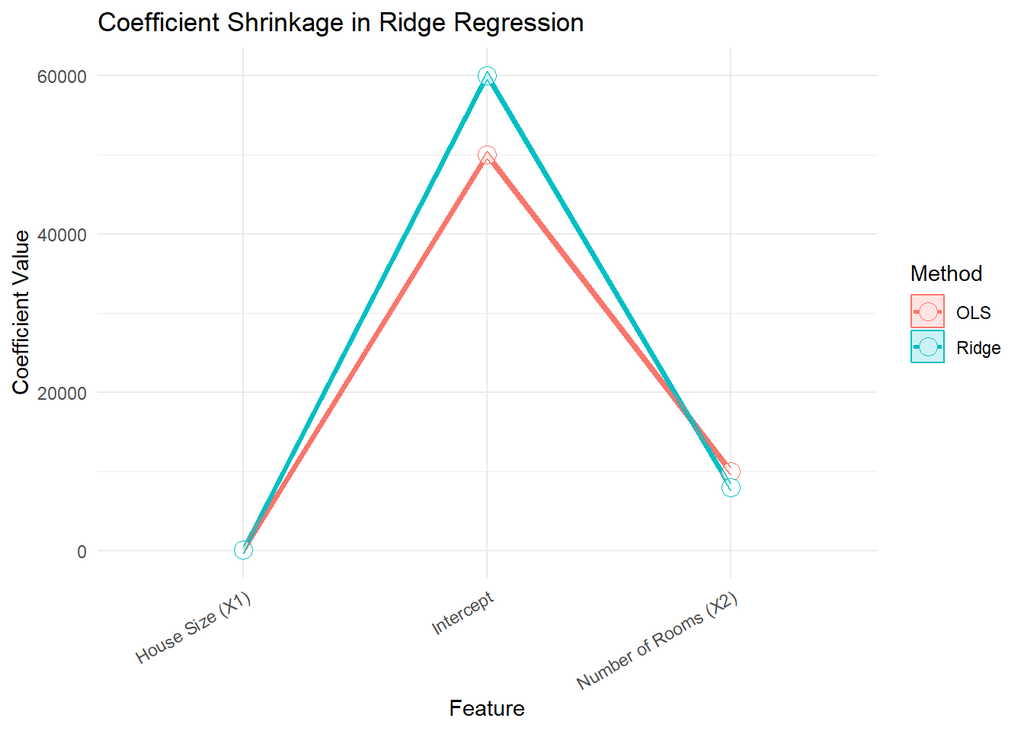

```r
library(ggplot2)
library(reshape2)

# Define dataset based on provided table
data <- data.frame(
  House_Size = c(1400, 1600, 1700, 1875, 1100),
  Number_of_Rooms = c(3, 3, 4, 4, 2),
  Price = c(300000, 320000, 340000, 360000, 280000)
)

# Simulating coefficients from OLS and Ridge Regression
coefficients <- data.frame(
  Feature = c("Intercept", "House Size (X1)", "Number of Rooms (X2)"),
  OLS = c(50000, 150, 10000),
  Ridge = c(60000, 120, 8000)
)

# Reshape data for ggplot
coefficients_melted <- melt(coefficients, id.vars = "Feature",
                             variable.name = "Method", value.name = "Coefficient")

# Line graph with grey area
line_plot <- ggplot(coefficients_melted, aes(x = Feature, y = Coefficient,
                                              group = Method, color = Method)) +
  geom_line(linewidth = 1) +
  geom_point(size = 4, shape = 21, fill = "white") +
  geom_ribbon(aes(ymin = Coefficient - 500, ymax = Coefficient + 500, fill = Method),
              alpha = 0.2) +
  theme_minimal() +
  labs(title = "Coefficient Shrinkage in Ridge Regression",
       x = "Feature",
       y = "Coefficient Value") +
  theme(axis.text.x = element_text(angle = 30, hjust = 1))

print(line_plot)
```

### Interpretation of the Line Plot: Coefficient Shrinkage in Ridge Regression

#### 1. Overview of the Plot

This plot compares the regression coefficients obtained using Ordinary Least Squares (OLS) and Ridge Regression for three features: - Intercept - House Size ($X_1$) - Number of Rooms ($X_2$)

The red line represents the OLS coefficients, and the blue line represents the Ridge coefficients. The circles indicate the exact coefficient values for each method.

## Benefits of Ridge Regression

1. **Bias-Variance Trade-off:** Ridge regression introduces a bias by shrinking coefficients but reduces variance. This trade-off often results in a lower mean squared error (MSE) compared to OLS for unseen data.
2. **Handles High-Dimensional Data:** Ridge regression can perform well even when the number of predictors exceeds the number of observations ($p > n$), where OLS fails.
3. **Improved Prediction Accuracy:** By stabilizing coefficients and controlling model complexity, ridge regression often yields better predictive performance.

### Applications of Ridge Regression

- **Genomics and Bioinformatics:** Handling thousands of predictors in genetic studies.
- **Environmental Studies:** Modeling pollution levels with highly correlated variables.
- **Finance:** Predicting stock prices with numerous and often correlated economic indicators.

## Comparison to OLS: Effect of Ridge Regularization

### OLS

In ordinary least squares, we minimize the sum of squared residuals:

$$\min_{\beta} \sum(y_i -
\hat{y}_i)^2$$

The coefficients are found by solving this optimization problem.

### Ridge Regression

Ridge modifies this by adding a penalty term for the sum of squared coefficients:

$$\min_{\beta} \sum(y_i - \hat{y}_i)^2 +
\lambda\sum\beta_j^2$$

The term $\lambda\sum\beta_j^2$ is the regularization term, with $\lambda$ being a hyperparameter that controls the strength of the regularization. When $\lambda = 0$, Ridge regression is equivalent to OLS, but as $\lambda$ increases, the coefficients shrink more, leading to a simpler and more regularized model.

### Impact of the Penalty

The penalty term shrinks the coefficients towards zero, as opposed to OLS, which allows them to grow arbitrarily large in order to fit the data exactly. This leads to a more robust model, particularly when the number of predictors is large or there is multicollinearity among them.

## Applying Ridge Regression to the Internet Linear Dataset

### Geometric Intuition of Ridge Regression

Ridge regression introduces a penalty term that shrinks the regression coefficients towards zero. This effect can be visualized through coefficient shrinkage diagrams. The regularization helps prevent overfitting and ensures a more stable model when predictors are highly correlated.

### Coefficient Shrinkage Visualization

Using the `internetlinear.csv` dataset, we analyze how Ridge regression affects coefficient shrinkage compared to OLS.

```r
library(readr)
internetlinear <- read_csv("internetlinear.csv")
View(internetlinear)
```

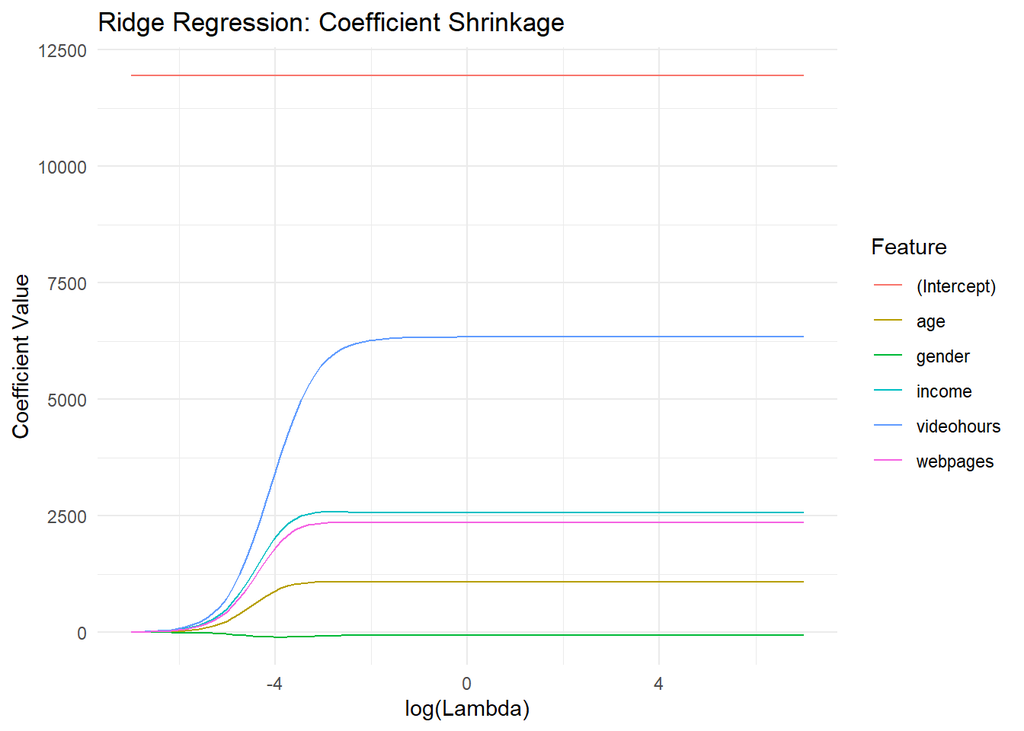

```r
library(ggplot2)
library(glmnet)
library(dplyr)
library(tidyr)

# Define predictors and target variable
X <- internetlinear %>% select(-usage)
y <- internetlinear$usage

# Standardize the predictors
X_scaled <- scale(X)

# Fit Ridge regression for different lambda values
lambda_values <- 10^seq(-7, 7, length.out = 100)
ridge_model <- glmnet(X_scaled, y, alpha = 0, lambda = lambda_values)

# Extract coefficients properly
ridge_coefs <- as.matrix(coef(ridge_model))
ridge_coefs <- as.data.frame(t(ridge_coefs))
ridge_coefs$lambda <- lambda_values

# Reshape for plotting
ridge_coefs <- ridge_coefs %>%
  pivot_longer(cols = -lambda, names_to = "Feature", values_to = "Coefficient")

# Plot coefficient shrinkage
ggplot(ridge_coefs, aes(x = log10(lambda), y = Coefficient, color = Feature)) +
  geom_line() +
  labs(title = "Ridge Regression: Coefficient Shrinkage",
       x = "log(Lambda)",
       y = "Coefficient Value") +
  theme_minimal()
```

## Exhaustive Interpretation of Ridge Regression Coefficient Shrinkage Plot

### Plot Overview

**Legend (Feature):** Displays the different features in the model. Different colors correspond to different predictors.

## L2 Regularization in Ridge Regression

### What is L2 Regularization?

L2 regularization, also known as Tikhonov regularization, is the mathematical technique used in Ridge Regression to prevent overfitting by adding a penalty term to the loss function.

**Standard OLS Objective:**

$$\min_{\beta} \sum(y_i -
\hat{y}_i)^2$$

**Ridge Regression (L2 Regularization) Objective:**

$$\min_{\beta} \sum(y_i - \hat{y}_i)^2 +
\lambda\sum\beta_j^2$$

where: - $\lambda$ is the regularization parameter (tuning strength of penalty). - $\sum\beta_j^2$ is the L2 penalty term, which forces large coefficients to shrink but never completely to zero.

### Why Does Ridge Regression Shrink Coefficients?

- Ridge regression reduces overfitting by discouraging large coefficient values.
- The larger the $\lambda$, the more shrinkage is applied to the coefficients.
- Unlike Lasso regression, Ridge does not perform feature selection—it retains all predictors, just shrinking them.

### What Types of Variables Does Ridge Regression Shrink?

#### Variables That Are Shrunk (Most Affected by L2 Regularization)

1. **Continuous Numeric Variables:**
   - Variables with large coefficient values shrink significantly.
   - Examples: `income`, `videohours`, `webpages`
   - Why? Ridge regression penalizes large coefficients to prevent overfitting.
2. **Correlated Variables (Multicollinearity Impact):**
   - Ridge is highly effective when features are correlated.
   - Instead of arbitrarily selecting one variable, Ridge shrinks all correlated coefficients together.
   - Example: If `income` and `webpages` are highly correlated, Ridge ensures neither dominates the model.
3. **Polynomial & Interaction Terms:**
   - If a model includes polynomial terms ($X^2, X^3$), Ridge shrinks these terms more aggressively than linear terms.
   - Why? Higher-order terms contribute more to overfitting.

#### Variables That Are Not Shrunk (Or Minimally Affected)

1. **Intercept ($\beta_0$):**
   - Ridge regression does not penalize the intercept to ensure proper model scaling.
2. **Categorical Variables (Dummy Variables, One-Hot Encoding):**
   - Example: `gender` (0 = Female, 1 = Male).
   - Why? Since binary variables take values 0 or 1, excessive shrinkage could distort categorical effects.

### The Impact of Different $\lambda$ Values

| $\lambda$ Value | Effect on Coefficients | Interpretation |
| --- | --- | --- |
| Small ($\lambda \approx 0$) | Almost no shrinkage | Model behaves like OLS (risk of overfitting) |
| Moderate ($\lambda > 4$) | Coefficients shrink | Controls variance and improves generalization |
| Large ($\lambda$) | Heavy shrinkage | Model becomes too simple (risk of underfitting) |

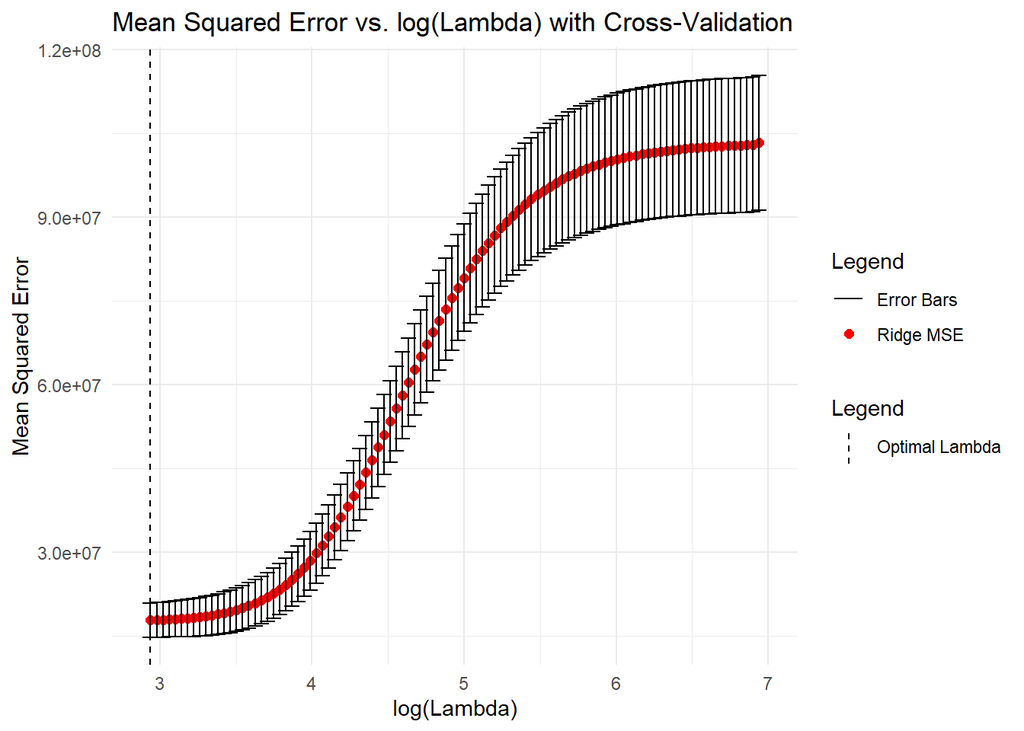

```r
data <- as.data.frame(internetlinear)

# Exclude categorical variables
X <- data[, !(names(data) %in% c("usage", "gender"))]
y <- data$usage

# Standardize the predictors
X_scaled <- scale(X)

# Fit Ridge Regression using Cross-Validation
set.seed(42)
cv_ridge <- cv.glmnet(X_scaled, y, alpha = 0, nfolds = 10)

# Extract relevant data
lambda_values <- cv_ridge$lambda
mse_values <- cv_ridge$cvm
mse_sd <- cv_ridge$cvsd
lambda_opt <- cv_ridge$lambda.min

# Create dataframe for visualization
mse_df <- data.frame(
  log_lambda = log10(lambda_values),
  MSE = mse_values,
  MSE_upper = mse_values + mse_sd,
  MSE_lower = mse_values - mse_sd
)

# Plot with legend
ggplot(mse_df, aes(x = log_lambda, y = MSE)) +
  geom_point(aes(color = "Ridge MSE"), size = 2) +
  geom_errorbar(aes(ymin = MSE_lower, ymax = MSE_upper, color = "Error Bars"), width = 0.1) +
  geom_vline(aes(xintercept = log10(lambda_opt), linetype = "Optimal Lambda"), color = "black") +
  scale_color_manual(name = "Legend", values = c("Ridge MSE" = "red", "Error Bars" = "black")) +
  scale_linetype_manual(name = "Legend", values = c("Optimal Lambda" = "dashed")) +
  labs(title = "Mean Squared Error vs. log(Lambda) with Cross-Validation",
       x = "log(Lambda)",
       y = "Mean Squared Error") +
  theme_minimal()
```

## Differences Between Linear, Ridge, and Lasso Regression

| Feature | Linear Regression | Ridge Regression | Lasso Regression |
| --- | --- | --- | --- |
| Equation | OLS: Minimizes SSE | $\min_{\beta}\sum(y_i-\hat{y}_i)^2+\lambda\sum\beta_j^2$ | $\min_{\beta}\sum(y_i-\hat{y}_i)^2+\lambda\sum\\|\beta_j\\|$ |
| Regularization Type | No Regularization | L2 Regularization | L1 Regularization |
| Penalty Term | No penalty applied | $\lambda\sum\beta_j^2$ | $\lambda\sum\\|\beta_j\\|$ |
| Effect on Coefficients | Uses OLS estimates | Shrinks coefficients but not to zero | Shrinks coefficients and can make some zero |
| Feature Selection | No | No, all features contribute | Yes, irrelevant features removed |
| Bias-Variance Tradeoff | Low bias, high variance | Slightly higher bias, lower variance | Higher bias, lower variance |
| Computational Complexity | Moderate | Higher | Higher |
| When to Use | No multicollinearity | Multicollinearity present, all features useful | Multicollinearity present, feature selection needed |
| Handling Multicollinearity | Poor | Stabilizes coefficients | Eliminates unimportant coefficients |
| Overfitting | Prone to overfitting | Reduces overfitting | Strongly reduces overfitting |

## Where is Ridge Regression Preferred?

Ridge regression is preferred in scenarios where multicollinearity is present, and we want to retain all features while preventing overfitting. Here are specific cases where Ridge Regression is the best choice:

### 1. Multicollinearity in Data

**What happens in Linear Regression?** - When predictor variables (features) are highly correlated, the OLS method produces unstable coefficients (large swings in values with small changes in data).

**Why Ridge Regression?** - Ridge stabilizes the coefficient estimates by adding an L2 penalty, ensuring the model is more robust and less sensitive to multicollinearity.

**Example:** - Stock market data, where multiple factors (interest rates, economic indicators, etc.) are correlated. - Medical datasets, where different tests measure similar health factors.

### 2. Large Number of Predictors (High-Dimensional Data)

**What happens in Linear Regression?** - When the number of predictors is large (e.g., thousands of variables), OLS estimates tend to overfit.

**Why Ridge Regression?** - Ridge shrinks coefficients and prevents overfitting, making it useful in high-dimensional datasets.

**Example:** - Genomics (e.g., predicting diseases using thousands of genetic markers). - Image Processing (e.g., feature selection in computer vision models).

### 3. When All Features Are Important

**What happens in Lasso Regression?** - Lasso sets some coefficients exactly to zero, removing some features completely.

**Why Ridge Regression?** - If we believe that all features contribute to the outcome, Ridge is a better choice since it shrinks coefficients without eliminating features.

**Example:** - Weather Forecasting (where every factor like temperature, humidity, pressure, etc., has an impact). - Financial Modeling (where multiple economic indicators affect the outcome).

### 4. When Interpretability is Not a Priority

**Why Ridge and Not Lasso?** - Ridge regression does not eliminate variables, making interpretation harder. - If you need a simpler, more interpretable model with fewer variables, Lasso is better. - If you want a robust model that retains all variables, Ridge is the right choice.

**Example:** - Machine Learning Pipelines (where interpretability is secondary to performance).

### 5. When You Have Slightly More Predictors Than Observations

- If the number of features is slightly greater than the number of samples, Ridge regression helps avoid overfitting.
- If there are many more features than observations, Ridge still works, but sometimes Lasso or Elastic Net might be better.

**Example:** - Predicting customer behavior in e-commerce (where data is sparse but has many features).

## Disadvantages of Ridge Regression

1. **Does Not Perform Feature Selection** - Ridge regression shrinks coefficients but does not set any to zero. This means it keeps all predictors in the model, even if some have little impact. Unlike Lasso regression, it cannot remove irrelevant variables completely.
2. **Sensitive to Feature Scaling** - Since ridge regression is based on penalizing the size of coefficients, the scale of the predictors matters. If features are not standardized, the model might assign too much weight to variables with larger ranges.
3. **Not Ideal When All Features Are Important** - If all predictors in the dataset are relevant and contribute equally to the response variable, ridge regression may unnecessarily shrink some coefficients, reducing model interpretability and predictive accuracy.

## Implementation

### Effect of Lambda on Coefficients

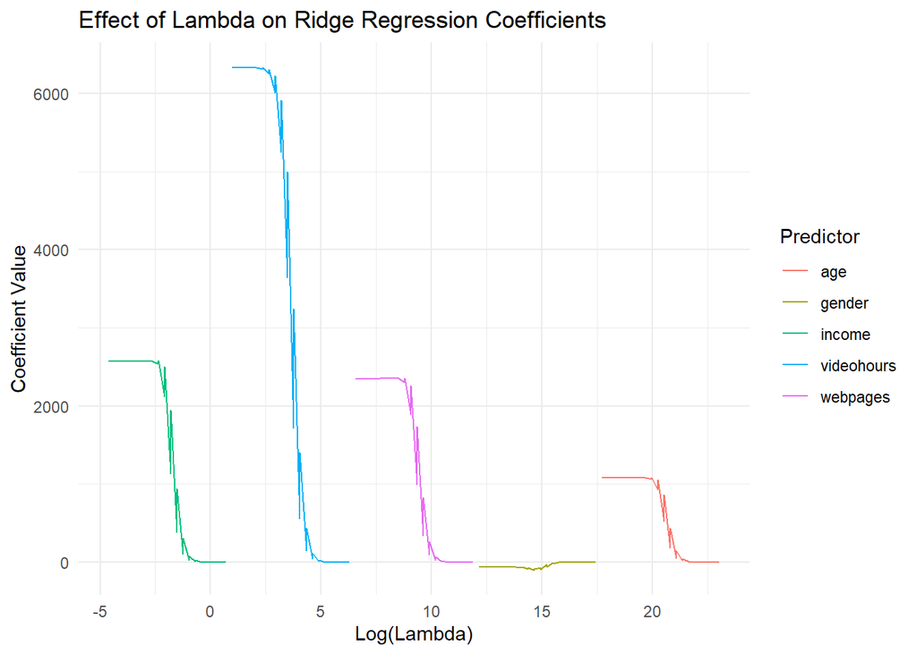

```r
# Load necessary libraries
library(glmnet)
library(ggplot2)
library(dplyr)
library(tidyr)

data <- read_csv("internetlinear.csv")
# Separate predictors (X) and target variable (y)
X <- as.matrix(data[, c("age", "gender", "webpages", "videohours", "income")])
y <- data$usage

# Standardize the predictors
X <- scale(X)

# Perform cross-validation to find the optimal lambda
set.seed(1556)
cv_ridge <- cv.glmnet(X, y, alpha = 0, nfolds = 10)

# Fit Ridge Regression for a range of lambda values
lambda_values <- 10^seq(10, -2, length = 100)
ridge_model <- glmnet(X, y, alpha = 0, lambda = lambda_values)

# Extract coefficients for each lambda
coefficients <- coef(ridge_model, s = lambda_values)

# Convert coefficients to a data frame for visualization
coef_df <- as.data.frame(as.matrix(coefficients))
coef_df <- coef_df[-1, ]
coef_df$predictor <- rownames(coef_df)

# Reshape the data for ggplot
coef_df_long <- coef_df %>%
  pivot_longer(cols = -predictor, names_to = "lambda_index", values_to = "coefficient") %>%
  mutate(lambda = rep(log(lambda_values), each = nrow(coef_df)))

# Plot the effect of lambda on coefficients
ggplot(coef_df_long, aes(x = lambda, y = coefficient, color = predictor)) +
  geom_line() +
  labs(
    title = "Effect of Lambda on Ridge Regression Coefficients",
    x = "Log(Lambda)",
    y = "Coefficient Value",
    color = "Predictor"
  ) +
  theme_minimal()
```

#### Observations:

- As the regularization parameter (lambda) increases, the coefficients of all predictors shrink towards zero.
- The rate of shrinkage differs between predictors; some shrink faster than others, indicating they are less influential in the model.
- At very high lambda values, coefficients approach zero, resulting in a heavily simplified model.

#### Interpretation:

- Small values of lambda produce coefficients similar to those in OLS regression, indicating minimal regularization.
- Large values of lambda apply significant penalties, reducing the influence of less important predictors.
- The optimal lambda (identified via cross-validation) balances model complexity and predictive performance.

#### Conclusion:

The plot demonstrates how Ridge Regression helps control over-fitting by shrinking coefficients. The optimal lambda ensures the model generalizes well without losing critical predictive information.

### Ridge vs. OLS Coefficients Comparison

```r
data <- read_csv("internetlinear.csv")
# Separate predictors (X) and target variable (y)
X <- as.matrix(data[, c("age", "webpages", "videohours", "income")])
y <- data$usage

# Standardize the predictors
X <- scale(X)

# Perform cross-validation to find the optimal lambda
set.seed(1556)
cv_ridge <- cv.glmnet(X, y, alpha = 0, nfolds = 10)

# Extract the optimal lambda value for Ridge
optimal_lambda <- cv_ridge$lambda.min
cat("Optimal Lambda for Ridge:", optimal_lambda, "\n")
```

```
## Optimal Lambda for Ridge: 868.2512
```

```r
# Fit Ridge Regression for the optimal lambda
ridge_model <- glmnet(X, y, alpha = 0, lambda = optimal_lambda)

# Extract coefficients for Ridge model
ridge_coefficients <- coef(ridge_model, s = optimal_lambda)
ridge_coefficients <- as.matrix(ridge_coefficients)

if (nrow(ridge_coefficients) > 1) {
  ridge_coef_df <- data.frame(predictor = rownames(ridge_coefficients)[-1],
                               coefficient = ridge_coefficients[-1, 1])
  ridge_coef_df$model <- "Ridge"

  cat("Ridge Regression Coefficients:\n")
  print(ridge_coef_df)
} else {
  print("No coefficients extracted from Ridge model.")
}
```

```
## Ridge Regression Coefficients:
##             predictor coefficient model
## age               age    1079.113 Ridge
## webpages     webpages    2350.506 Ridge
## videohours videohours    5833.906 Ridge
## income         income    2584.740 Ridge
```

```r
# Fit OLS model
ols_model <- lm(y ~ X)
ols_coefficients <- coef(ols_model)[-1]

# Convert OLS coefficients to a data frame
ols_coef_df <- data.frame(predictor = names(ols_coefficients),
                           coefficient = ols_coefficients)
ols_coef_df$model <- "OLS"

cat("OLS Regression Coefficients:\n")
```

```
## OLS Regression Coefficients:
```

```r
print(ols_coef_df)
```

```
##               predictor coefficient model
## Xage               Xage    1078.394   OLS
## Xwebpages     Xwebpages    2349.986   OLS
## Xvideohours Xvideohours    6339.377   OLS
## Xincome         Xincome    2570.790   OLS
```

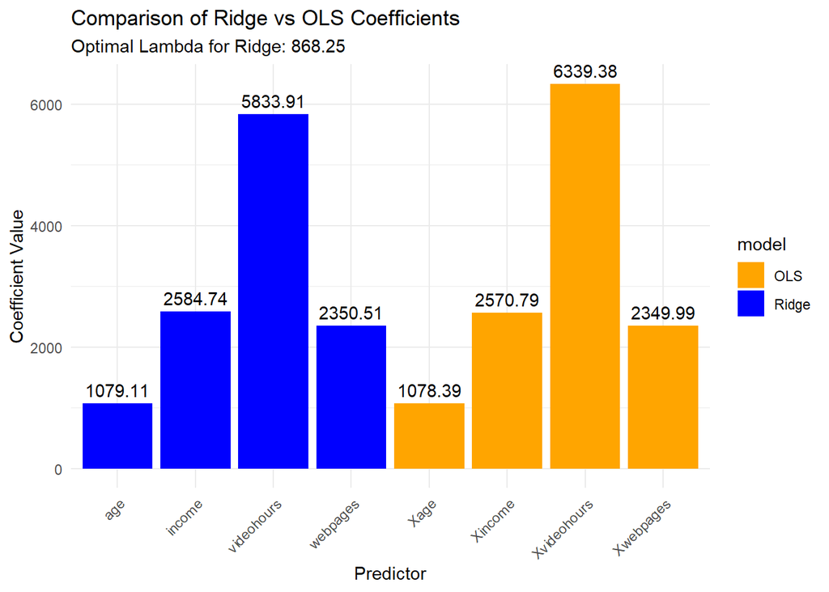

```r
# Combine all coefficients
coef_comparison_df <- rbind(ridge_coef_df, ols_coef_df)

# Create a bar plot
ggplot(coef_comparison_df, aes(x = predictor, y = coefficient, fill = model)) +
  geom_bar(stat = "identity", position = "dodge") +
  geom_text(aes(label = round(coefficient, 2)), position = position_dodge(0.8), vjust = -0.5) +
  labs(title = "Comparison of Ridge vs OLS Coefficients",
       subtitle = paste("Optimal Lambda for Ridge:", round(optimal_lambda, 2)),
       x = "Predictor", y = "Coefficient Value") +
  scale_fill_manual(values = c("Ridge" = "blue", "OLS" = "orange")) +
  theme_minimal() +
  theme(axis.text.x = element_text(angle = 45, hjust = 1))
```

#### Interpretation:

- Ridge Regression adjusts coefficients to minimize both the residual sum of squares and the penalty term.
- The OLS model does not penalize coefficients, so it assigns weights solely based on minimizing residual error.

#### Conclusion:

- The higher Ridge coefficient for `income` suggests that this variable has a stronger overall relationship with the target variable, `usage`, when considered in a regularized context.
- Ridge Regression emphasizes the stability of the model over the magnitude of individual coefficients.

## Comparison with Lasso and Elastic Net Regression

### Observation:

- **Ridge Regression** applies a penalty to shrink all coefficients but never eliminates predictors.
- **Lasso Regression** introduces sparsity by shrinking some coefficients to exactly zero, effectively removing irrelevant predictors.
- **Elastic Net** combines the penalties of Ridge and Lasso, striking a balance between reducing multicollinearity and performing feature selection.

### Interpretation:

- Ridge Regression excels when multicollinearity is present, as it reduces the variability in coefficient estimates without discarding any predictors.
- Lasso is most useful when there are many predictors, and some are likely irrelevant.
- Elastic Net is versatile for datasets where predictors exhibit multicollinearity, and the model also needs to identify and remove irrelevant predictors.

### Conclusion:

- **When to use Ridge:** When all predictors are expected to influence the target variable, even if their effects are small.
- **When to use Lasso:** For high-dimensional data or scenarios where only a subset of predictors is believed to be truly significant.
- **When to use Elastic Net:** When predictors are both highly correlated and when some predictors are expected to be irrelevant.

## Part 10: Implementation - Model Performance

### 1. Model Performance

```r
library(glmnet)
library(ggplot2)
library(dplyr)
library(tidyr)
library(caret)
library(car)

# Display structure of dataset
str(internetlinear)
```

```
## spc_tbl_ [966 × 6] (S3: spec_tbl_df/tbl_df/tbl/data.frame)
##  $ age       : num [1:966] 28 26 30 26 20 58 44 39 44 46 ...
##  $ gender    : num [1:966] 0 0 1 1 1 1 1 1 0 1 ...
##  $ webpages  : num [1:966] 23 27 58 25 17 18 17 28 24 46 ...
##  $ videohours: num [1:966] 0 0 11.55 11.99 1.94 ...
##  $ income    : num [1:966] 4099 2677 6215 7626 8071 ...
##  $ usage     : num [1:966] 875 1792 27754 28256 4438 ...
##  - attr(*, "spec")=
##   .. cols(
##   ..   age = col_double(),
##   ..   gender = col_double(),
##   ..   webpages = col_double(),
##   ..   videohours = col_double(),
##   ..   income = col_double(),
##   ..   usage = col_double()
##   .. )
##  - attr(*, "problems")=<externalptr>
```

```r
summary(internetlinear)
```

```
##       age            gender          webpages        videohours
##  Min.   :19.00   Min.   :0.0000   Min.   : 10.00   Min.   : 0.0000
##  1st Qu.:27.00   1st Qu.:0.0000   1st Qu.: 20.00   1st Qu.: 0.4106
##  Median :37.00   Median :1.0000   Median : 25.00   Median : 1.7417
##  Mean   :37.94   Mean   :0.5124   Mean   : 29.64   Mean   : 4.0229
##  3rd Qu.:48.75   3rd Qu.:1.0000   3rd Qu.: 32.00   3rd Qu.: 4.7765
##  Max.   :60.00   Max.   :1.0000   Max.   :950.00   Max.   :45.0000
##      income          usage
##  Min.   :    0   Min.   :   500
##  1st Qu.: 3503   1st Qu.:  3607
##  Median : 6362   Median :  9155
##  Mean   : 6179   Mean   : 11955
##  3rd Qu.: 8652   3rd Qu.: 19361
##  Max.   :12000   Max.   :108954
```

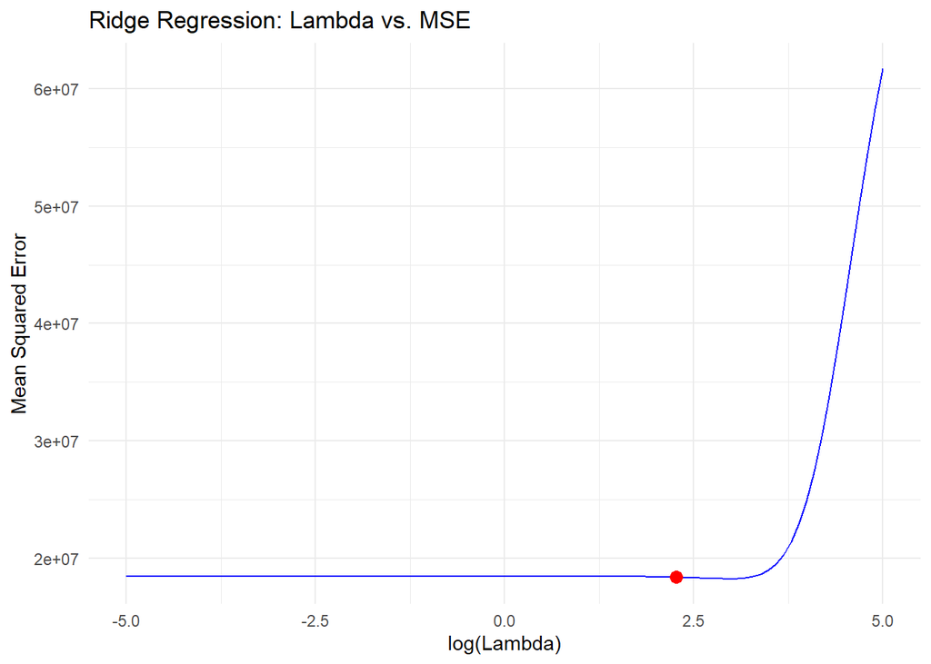

```r
# Define predictors and target variable
X <- internetlinear[, c("age", "webpages", "videohours", "income")]
y <- internetlinear$usage

# Standardize the predictors
X_scaled <- scale(X)
X_scaled_df <- as.data.frame(X_scaled)
X_scaled_df$usage <- y

# Split data into training (80%) and testing (20%)
set.seed(42)
train_indices <- sample(seq_len(nrow(X_scaled_df)), size = 0.8 * nrow(X_scaled_df))
train_data <- X_scaled_df[train_indices, ]
test_data <- X_scaled_df[-train_indices, ]

X_train <- train_data[, -ncol(train_data)]
X_test <- test_data[, -ncol(test_data)]
y_train <- train_data$usage
y_test <- test_data$usage

# 1. Ordinary Least Squares (OLS)
ols_model <- lm(usage ~ ., data = train_data)
ols_predictions <- predict(ols_model, newdata = test_data)

# Compute OLS Performance Metrics
ols_mse <- mean((y_test - ols_predictions)^2)
ols_r2 <- 1 - sum((y_test - ols_predictions)^2) / sum((y_test - mean(y_test))^2)

# 2. Ridge Regression
set.seed(42)
lambda_values <- 10^seq(-5, 5, length.out = 100)
ridge_model <- glmnet(as.matrix(X_train), y_train, alpha = 0, lambda = lambda_values)

# Find optimal lambda via cross-validation
cv_ridge <- cv.glmnet(as.matrix(X_train), y_train, alpha = 0, lambda = lambda_values, nfolds = 10)
ridge_lambda_opt <- cv_ridge$lambda.min

# Make predictions with optimal Ridge model
ridge_predictions <- predict(ridge_model, s = ridge_lambda_opt, newx = as.matrix(X_test))

# Compute Ridge Performance Metrics
ridge_mse <- mean((y_test - ridge_predictions)^2)
ridge_r2 <- 1 - sum((y_test - ridge_predictions)^2) / sum((y_test - mean(y_test))^2)

# 3. Compare Model Performance at Different Lambda Values
ridge_mse_values <- sapply(lambda_values, function(l) {
  predictions <- predict(ridge_model, s = l, newx = as.matrix(X_test))
  mean((y_test - predictions)^2)
})

lambda_comparison_df <- data.frame(
  Lambda = lambda_values,
  MSE = ridge_mse_values
)

# Plot Lambda vs. MSE
ggplot(lambda_comparison_df, aes(x = log10(Lambda), y = MSE)) +
  geom_line(color = "blue") +
  geom_point(aes(x = log10(ridge_lambda_opt), y = ridge_mse), color = "red", size = 3) +
  labs(title = "Ridge Regression: Lambda vs. MSE",
       x = "log(Lambda)", y = "Mean Squared Error") +
  theme_minimal()
```

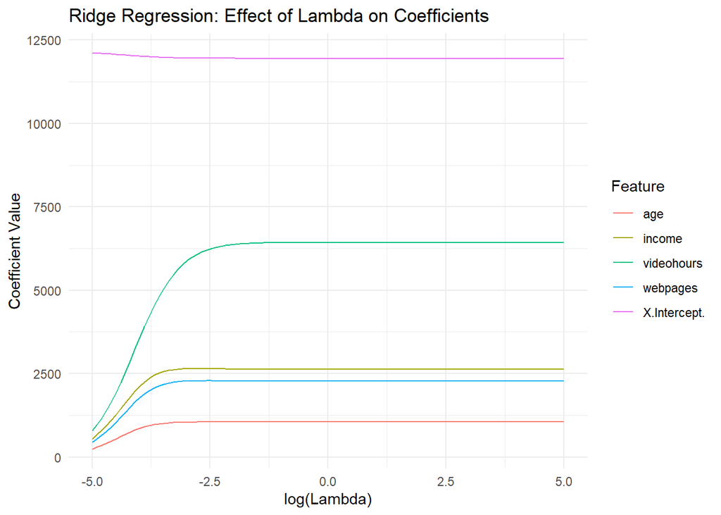

```r
# 4. Compare Ridge Coefficients Across Different Lambda Values
ridge_coefficients <- as.matrix(coef(ridge_model))
ridge_coefficients_df <- data.frame(t(ridge_coefficients))
ridge_coefficients_df$Lambda <- lambda_values

# Reshape for plotting
ridge_coefficients_long <- ridge_coefficients_df %>%
  pivot_longer(cols = -Lambda, names_to = "Feature", values_to = "Coefficient")

# Plot coefficient shrinkage
ggplot(ridge_coefficients_long, aes(x = log10(Lambda), y = Coefficient, color = Feature)) +
  geom_line() +
  labs(title = "Ridge Regression: Effect of Lambda on Coefficients",
       x = "log(Lambda)", y = "Coefficient Value") +
  theme_minimal()
```

```r
# 5. Model Performance Comparison
performance_df <- data.frame(
  Model = c("OLS", "Ridge Regression (Optimal Lambda)"),
  MSE = c(ols_mse, ridge_mse),
  R2 = c(ols_r2, ridge_r2)
)

print("Model Performance Comparison:")
```

```
## [1] "Model Performance Comparison:"
```

```r
print(performance_df)
```

```
##                               Model      MSE        R2
## 1                               OLS 18454658 0.7666970
## 2 Ridge Regression (Optimal Lambda) 18366683 0.7678092
```

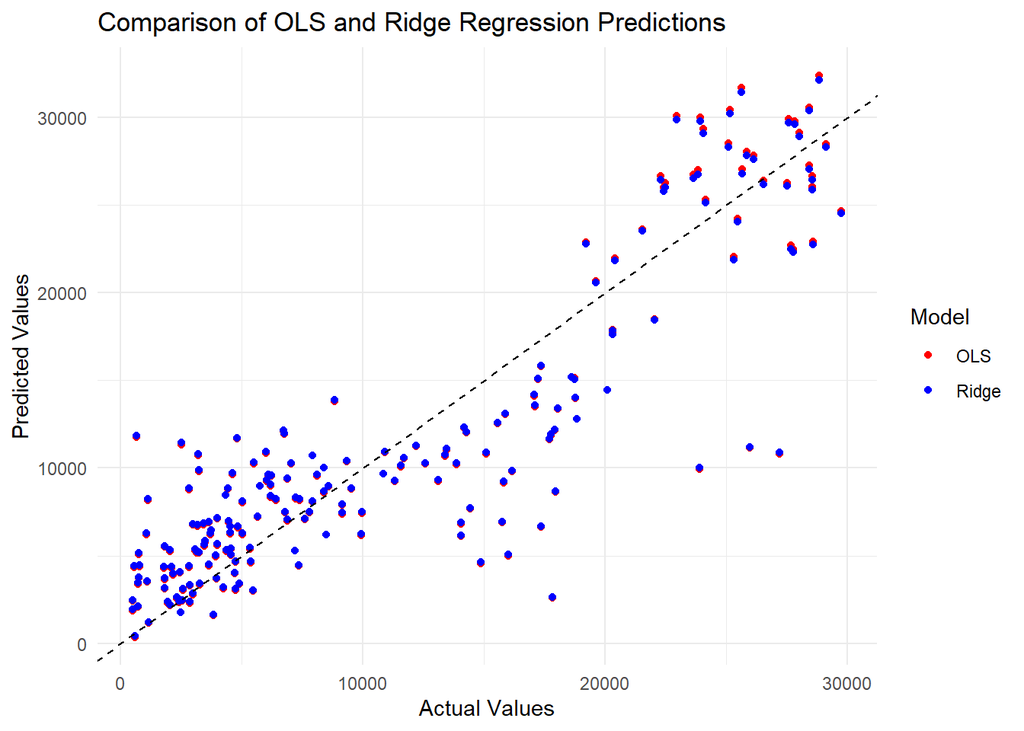

```r
# 6. Actual vs Predicted Plot
ols_vs_ridge_df <- data.frame(
  Actual = y_test,
  OLS_Predicted = ols_predictions,
  Ridge_Predicted = as.vector(ridge_predictions)
)

ggplot(ols_vs_ridge_df, aes(x = Actual)) +
  geom_point(aes(y = OLS_Predicted, color = "OLS")) +
  geom_point(aes(y = Ridge_Predicted, color = "Ridge")) +
  geom_abline(slope = 1, intercept = 0, color = "black", linetype = "dashed") +
  labs(title = "Comparison of OLS and Ridge Regression Predictions",
       x = "Actual Values", y = "Predicted Values") +
  scale_color_manual(name = "Model", values = c("OLS" = "red", "Ridge" = "blue")) +
  theme_minimal()
```

### Interpretation

#### Observations:

- The calculated R-squared value indicates how well the model explains variance in the data.
- If R² is close to 1, the model fits the data well; if near 0, it has poor predictive power.

#### Model Performance Results:

1. The OLS model has an MSE of approximately 18,454,658 and an R² of 0.767. This means about 76.7% of the variability in usage is explained by the predictors.
2. The Ridge Regression model (with optimal lambda) has a slightly lower MSE of 18,366,683 and a slightly higher R² of 0.768.
3. Although the differences are small, the improvement with Ridge regression can be meaningful when predictors are correlated or when overfitting is a concern.

#### Conclusion:

- A high R² suggests that Ridge Regression effectively captures the relationship between predictors and internet usage.
- The model’s performance validates the effectiveness of Ridge Regression.
- The regularization penalty ensures a stable, generalizable model that minimizes prediction errors.

## Practical Comparison of OLS vs RIDGE

### Handling Highly Correlated Predictors

When predictors are highly correlated, OLS can yield unstable estimates because it tries to fit the data exactly without any constraint. In practice, this might force you to remove or merge correlated variables to avoid multicollinearity, potentially discarding useful information. In contrast, Ridge regression tackles multicollinearity by penalizing the size of the coefficients (after scaling), which shrinks them without removing any predictors from the model.

Thus, when dealing with highly correlated variables:

- **OLS** may perform poorly unless you manually adjust the model (by removing or combining predictors), which can be both arbitrary and lead to loss of information.
- **Ridge Regression** automatically stabilizes the coefficient estimates through regularization, retaining all predictors while reducing the risk of overfitting.

## Why videohours Shows Longer Shrinkage

The graph for `videohours` looks longer than `age` or others because its coefficient changes more as lambda increases. This happens for a few reasons:

1. **Larger Initial Coefficient:** `videohours` likely starts with a bigger coefficient, so the shrinkage effect is more noticeable.
2. **Stronger Predictor:** It might have a stronger relationship with the target (`usage`), so its coefficient is larger and shrinks more visibly.
3. **Scale Differences:** If `videohours` is on a larger scale (e.g., 0-100 vs. 0-1 for age), its coefficient could naturally be bigger, even after scaling.
4. **Multicollinearity:** If `videohours` is correlated with other predictors, ridge regression shrinks it more to reduce instability.